# BA_assignment3_sakshi

SAKSHI

2023-11-02

## Questions

**1. Run the following code in R-studio to create two variables X and Y.**

set.seed(2017)

X = runif(100)*10

Y = rnorm(100)*0.29*Y+Y

**a) Plot Y against X. Include a screenshot of the plot in your submission. Using the File menu you can save the graph as a picture on your computer. Based on the plot do you think we can fit a linear model to explain Y based on X? (8% of total points)**

**b) Construct a simple linear model of Y based on X. Write the equation that explains Y based on X. What is the accuracy of this model? (8% of total points)**

**c) How the Coefficient of Determination, $R^{2}$, of the model above is related to the correlation coefficient of X and Y? (8% of total points)**

**Answer.1**

```r
set.seed(2017)

X = runif(100)*10

Y = X*4+3.45

Y = rnorm(100)*0.29*Y+Y
```

**a.**

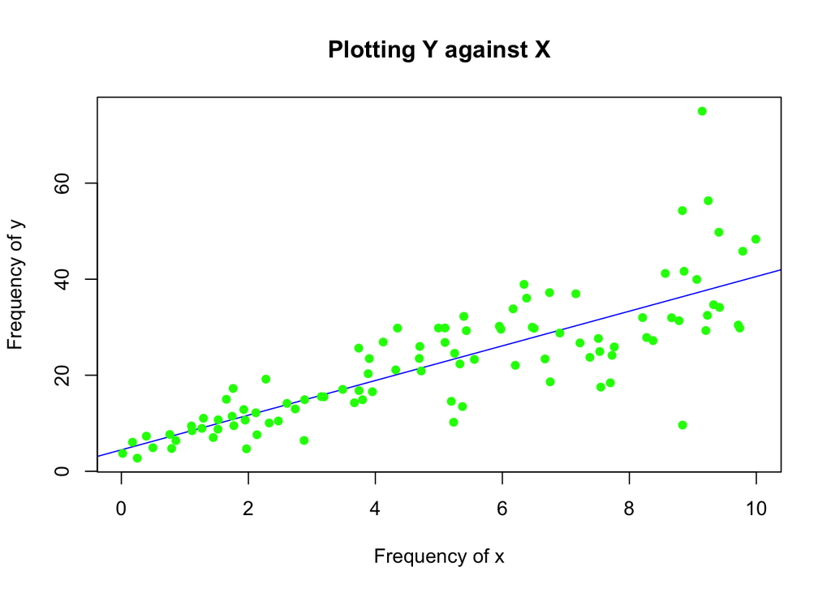

```r
plot(X , Y , xlab = 'Frequency of x' , ylab = 'Frequency of y' ,main = 'Plotting Y against X', col = 'green', pch = 16 ,frame.plot = TRUE, abline(lm(Y~X),col = 'blue'))
```

### Result

**b.**

```r
model <- lm(Y~X)

summary(model)
```

```
Call:
lm(formula = Y ~ X)

Residuals:
    Min      1Q  Median      3Q     Max
-26.755  -3.846  -0.387   4.318  37.503

Coefficients:
            Estimate Std. Error t value Pr(>|t|)
(Intercept)   4.4655     1.5537   2.874  0.00497 **
X             3.6108     0.2666  13.542  < 2e-16 ***
---
Signif. codes:  0 '***' 0.001 '**' 0.01 '*' 0.05 '.' 0.1 ' ' 1

Residual standard error: 7.756 on 98 degrees of freedom
Multiple R-squared:  0.6517,    Adjusted R-squared:  0.6482
F-statistic: 183.4 on 1 and 98 DF,  p-value: < 2.2e-16
```

The general equation of the model is defined as -

$\hat{y}$ = $b_0$ + $bx_{1}$ + $bx_{2}$ +…………..$bx_n$

Equation that explains Y based on X is-

$\hat{Y}$ = 4.4655 + 3.6108$x_{1}$

### Result

The accuracy of the model is 65% which is relatively high as we can see that the p value is really small and close to zero which mean that the relationship between both the variables is quite significant and X (independent variable) greatly influences the value of Y (dependent variable). Also, the difference between Multiple R-squared (0.6517) and Adjusted R-squared (0.6482) is very low, which indicates that we have made the right choice of variable and X will be successfully able to determine the value of Y by 65%.

**c.**

In a simple linear regression model (one independent variable), the square of the correlation coefficient (r) between X and Y is equal to the $R^{2}$ value.

Mathematically:

$R^{2}$ = $r^{2}$

```r
#Finding the square of correlation between X and Y

cor(X,Y)^2
```

```
[1] 0.6517187
```

As we can see above, both vales comes out to be **0.6517** .This relationship holds true because $R^{2}$ quantifies the proportion of the variance in Y that can be explained by X, which is the same information that is captured by the correlation coefficient (r).

**2.We will use the ‘mtcars’ dataset for this question. The dataset is already included in your R distribution. The dataset shows some of the characteristics of different cars. The following shows few samples (i.e. the first 6 rows) of the dataset. The description of the dataset can be found here.**

```r
head(mtcars)
```

```
                   mpg cyl disp  hp drat    wt  qsec vs am gear carb
Mazda RX4         21.0   6  160 110 3.90 2.620 16.46  0  1    4    4
Mazda RX4 Wag     21.0   6  160 110 3.90 2.875 17.02  0  1    4    4
Datsun 710        22.8   4  108  93 3.85 2.320 18.61  1  1    4    1
Hornet 4 Drive    21.4   6  258 110 3.08 3.215 19.44  1  0    3    1
Hornet Sportabout 18.7   8  360 175 3.15 3.440 17.02  0  0    3    2
Valiant           18.1   6  225 105 2.76 3.460 20.22  1  0    3    1
```

**a) James wants to buy a car. He and his friend, Chris, have different opinions about the Horse Power (hp) of cars. James think the weight of a car (wt) can be used to estimate the Horse Power of the car while Chris thinks the fuel consumption expressed in Mile Per Gallon (mpg),is a better estimator of the (hp). Who do you think is right? Construct simple linear models using mtcars data to answer the question. (17% of total points)**

**b) Build a model that uses the number of cylinders (cyl) and the mile per gallon (mpg) values of a car to predict the car Horse Power (hp). Using this model, what is the estimated Horse Power of a car with 4 calendar and mpg of 22? (17% of total points)**

**a.**

**Creating a linear model based on James’s opinion-**

```r
model_wt <- lm(hp ~ wt , data = mtcars)

summary(model_wt)
```

```
Call:
lm(formula = hp ~ wt, data = mtcars)

Residuals:
    Min      1Q  Median      3Q     Max
-83.430 -33.596 -13.587   7.913 172.030

Coefficients:
            Estimate Std. Error t value Pr(>|t|)
(Intercept)   -1.821     32.325  -0.056    0.955
wt            46.160      9.625   4.796 4.15e-05 ***
---
Signif. codes:  0 '***' 0.001 '**' 0.01 '*' 0.05 '.' 0.1 ' ' 1

Residual standard error: 52.44 on 30 degrees of freedom
Multiple R-squared:  0.4339,    Adjusted R-squared:  0.4151
F-statistic:    23 on 1 and 30 DF,  p-value: 4.146e-05
```

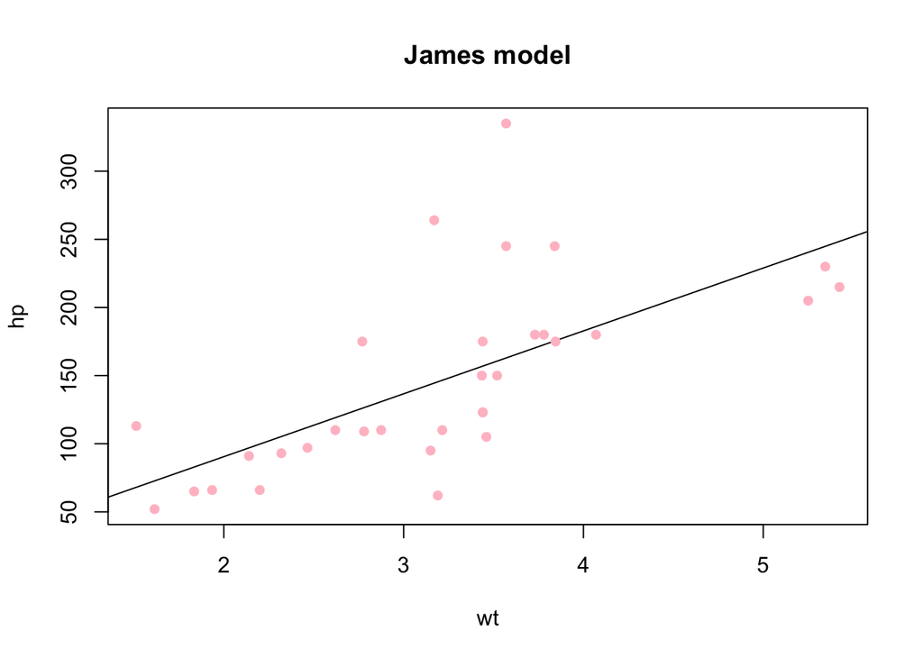

```r
# Plotting hp against wt.

plot(mtcars$wt , mtcars$hp , xlab = 'wt' , ylab = 'hp' ,main = 'James model', col = 'pink', pch = 16 ,frame.plot = TRUE, abline(lm(mtcars$hp ~ mtcars$wt),col = 'black'))
```

**Creating a linear model based on Chris’s opinion-**

```r
model_mpg <- lm(hp ~ mpg , data = mtcars)

summary(model_mpg)
```

```
Call:
lm(formula = hp ~ mpg, data = mtcars)

Residuals:
   Min     1Q Median     3Q    Max
-59.26 -28.93 -13.45  25.65 143.36

Coefficients:
            Estimate Std. Error t value Pr(>|t|)
(Intercept)   324.08      27.43  11.813 8.25e-13 ***
mpg            -8.83       1.31  -6.742 1.79e-07 ***
---
Signif. codes:  0 '***' 0.001 '**' 0.01 '*' 0.05 '.' 0.1 ' ' 1

Residual standard error: 43.95 on 30 degrees of freedom
Multiple R-squared:  0.6024,    Adjusted R-squared:  0.5892
F-statistic: 45.46 on 1 and 30 DF,  p-value: 1.788e-07
```

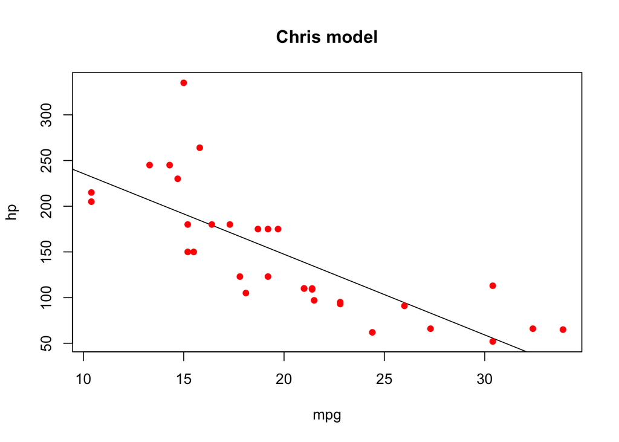

```r
# Plotting hp against mpg.

plot(mtcars$mpg , mtcars$hp , xlab = 'mpg' , ylab = 'hp' ,main = 'Chris model', col = 'red', pch = 16 ,frame.plot = TRUE, abline(lm(mtcars$hp ~ mtcars$mpg),col = 'black'))
```

**Comparing the two models based on their R-squared values and p-values.**

```r
# James's opinion
summary(model_wt)$r.squared
```

```
[1] 0.4339488
```

```r
summary(model_wt)$coefficients[, "Pr(>|t|)"]
```

```
 (Intercept)           wt
9.554506e-01 4.145827e-05
```

```r
# Chris's opinion
summary(model_mpg)$r.squared
```

```
[1] 0.6024373
```

```r
summary(model_mpg)$coefficients[, "Pr(>|t|)"]
```

```
 (Intercept)          mpg
8.245456e-13 1.787835e-07
```

### Result

From the above comparison, we can come to the conclusion that Chris opinion is right about mpg being the better estimator of the hp. This is because the r-squared value of Chris’s model is higher than that of James’s model i.e. the accuracy of Chris’s model is 60% as compared to 43% of James’s model. Also, the p-value of Chris’s model is smaller than 0.05 which indicates that there is a strong relationship between variables and mpg has a statistically higher significant effect on the hp than wt.

**b.**

```r
# Creating a base model

model_predict <- lm(hp ~ cyl + mpg , data = mtcars)

summary(model_predict)
```

```
Call:
lm(formula = hp ~ cyl + mpg, data = mtcars)

Residuals:
   Min     1Q Median     3Q    Max
-53.72 -22.18 -10.13  14.47 130.73

Coefficients:
            Estimate Std. Error t value Pr(>|t|)
(Intercept)   54.067     86.093   0.628  0.53492
cyl           23.979      7.346   3.264  0.00281 **
mpg           -2.775      2.177  -1.275  0.21253
---
Signif. codes:  0 '***' 0.001 '**' 0.01 '*' 0.05 '.' 0.1 ' ' 1

Residual standard error: 38.22 on 29 degrees of freedom
Multiple R-squared:  0.7093,    Adjusted R-squared:  0.6892
F-statistic: 35.37 on 2 and 29 DF,  p-value: 1.663e-08
```

Finding the value of hp with 4 cylinder and mpg of 22-

```r
predict_result <- predict(model_predict , newdata = data.frame(cyl = 4 , mpg = 22))

predict_result
```

```
       1
88.93618
```

### Result

The estimated Horse Power of a car with 4 cylinder and mpg of 22 is 88.93618.

**3. a) Build a model to estimate the median value of owner-occupied homes (medv)based on the following variables: crime crate (crim), proportion of residential land zoned for lots over 25,000 sq.ft (zn), the local pupil-teacher ratio (ptratio) and weather the whether the tract bounds Chas River(chas). Is this an accurate model? (Hint check R 2 ) (8% of total points)**

**b) Use the estimated coefficient to answer these questions?**

**I. Imagine two houses that are identical in all aspects but one bounds the Chas River and the other does not. Which one is more expensive and by how much? (8% of total points)**

**II. Imagine two houses that are identical in all aspects but in the neighborhood of one of them the pupil-teacher ratio is 15 and in the other one is 18. Which one is more expensive and by how much? (Golden Question: 4% extra)**

**c) Which of the variables are statistically important (i.e. related to the house price)? Hint: use the p-values of the coefficients to answer. (8% of total points)**

**d) Use the anova analysis and determine the order of importance of these four variables. (18%of total points)**

```r
library(mlbench)
data(BostonHousing)
```

**a.**

```r
boston_model <- lm(medv ~ crim + zn + ptratio + chas , data = BostonHousing)

summary(boston_model)
```

```
Call:
lm(formula = medv ~ crim + zn + ptratio + chas, data = BostonHousing)

Residuals:
    Min      1Q  Median      3Q     Max
-18.282  -4.505  -0.986   2.650  32.656

Coefficients:
            Estimate Std. Error t value Pr(>|t|)
(Intercept) 49.91868    3.23497  15.431  < 2e-16 ***
crim        -0.26018    0.04015  -6.480 2.20e-10 ***
zn           0.07073    0.01548   4.570 6.14e-06 ***
ptratio     -1.49367    0.17144  -8.712  < 2e-16 ***
chas1        4.58393    1.31108   3.496 0.000514 ***
---
Signif. codes:  0 '***' 0.001 '**' 0.01 '*' 0.05 '.' 0.1 ' ' 1

Residual standard error: 7.388 on 501 degrees of freedom
Multiple R-squared:  0.3599,    Adjusted R-squared:  0.3547
F-statistic: 70.41 on 4 and 501 DF,  p-value: < 2.2e-16
```

### Result

The model’s accuracy is not particularly high with an r-squared value of 35% and the residual error of 7.388 suggests that model’s predictions are about 7.388 units away from the actual value which is not a good trait of an accurate model. However, by looking at the p value and f-statistic, we can determine that model is statistically significant. We just need to include more variables that are affecting the median value of homes in order to improve the accuracy.

**b.**

**I**

Note: chas is a factorial variable, if the house bounds Chas river then the value is going to be 1 and if the house not bounds the Chas river the the value is 0.

Based on the above model built,

$$medv = intercept + crim + zn + ptratio +
chas$$

```r
#if the house bounds the Chas River then the price of that house is-

char_yes <-  (49.91868 + (-0.26018) + 0.07073 + (-1.49367) + 4.58393*(1))

#if the house does not bounds the Chas River then the price of that house is-

char_no <-  (49.91868 + (-0.26018) + 0.07073 + (-1.49367) + 4.58393*(0))

char_diff <- char_yes - char_no
```

### Result

Comparing from above, we can see that for Identical houses when chas factor is 1 (char_yes), the value as per estimated std is 52.81949 whereas when chas factor is 0 (char_no) the value as per estimated std. is 48.23556. By comparison of factors 1 and 0 (char_diff), chas River is expensive by 4.58393 for factor 1 in $1000.

**II**

Note: Pupil to Teacher ratio is per how many students a teacher has been allocated.

$$medv = intercept + crim + zn + ptratio +
chas$$

```r
#For 15 units of change in the pupil teacher ratio the price of the house is going to

ptratio_15 <-  (49.91868 + (-0.26018) + 0.07073 + 15*(-1.49367) + 4.58393)

#For 18 units of change in the pupil teacher ratio the price of the house is going to

ptratio_18 <-  (49.91868 + (-0.26018) + 0.07073 + 18*(-1.49367) + 4.58393)

ptratio_diff <- ptratio_15 - ptratio_18
```

### Result

The expensive house is going to be where the ptratio is 15 with a difference of 4.48101 in 1000$ with that to the pt ratio of 18.

**c.**

```r
significant_level <- summary(boston_model)$coefficients[, "Pr(>|t|)"]

significant_vars <- significant_level < 0.05

significant_vars
```

```
(Intercept)        crim          zn     ptratio       chas1
       TRUE        TRUE        TRUE        TRUE        TRUE
```

### Result

As we can see, that all p-value is less than 0.05 , it means that all the variables are statistically important and significantly related in determining the house price.

**d.**

```r
anova(boston_model)
```

```
Analysis of Variance Table

Response: medv
           Df  Sum Sq Mean Sq F value    Pr(>F)
crim        1  6440.8  6440.8 118.007 < 2.2e-16 ***
zn          1  3554.3  3554.3  65.122 5.253e-15 ***
ptratio     1  4709.5  4709.5  86.287 < 2.2e-16 ***
chas        1   667.2   667.2  12.224 0.0005137 ***
Residuals 501 27344.5    54.6
---
Signif. codes:  0 '***' 0.001 '**' 0.01 '*' 0.05 '.' 0.1 ' ' 1
```

### Result

Based on the F values and p-values, all predictors are statistically significant. However, to determine their relative importance, we can compare the F values or the sum of squares:

*crim*: F value of 118.007 with a sum of squares of 6440.8

*zn*: F value of 65.122 with a sum of squares of 3554.3

*ptratio*: F value of 86.287 with a sum of squares of 4709.5

*chas*: F value of 12.224 with a sum of squares of 667.2

The predictor with the highest F value and sum of squares is crim, followed by ptratio, zn, and chas. This suggests that crim contributes the most to the model, followed by ptratio, in terms of explaining the variability in the median value of owner-occupied homes. zn also makes a significant contribution, while chas, despite being statistically significant, contributes the least in terms of the sum of squares.

$$crim > ptratio > zn > chas$$

In conclusion, based on the ANOVA table, crim appears to be the most important variable in the model, followed by ptratio, zn, and chas, in that order.